# TermDeposit_Anupam

### Goal

Using the data collected from existing customers, build a model that will help the marketing team identify potential customers who are relatively more likely to subscribe term deposit and thus increase their hit ratio.

Input variables: Bank client data:

1. age: Continuous feature
2. job: Type of job (management, technician, entrepreneur, blue-collar, etc.)
3. marital: marital status (married, single, divorced)
4. education: education level (primary, secondary, tertiary)
5. default: has credit in default?
6. housing: has housing loan? Yes, No
7. loan: has personal loan? Yes, No
8. balance in account

Related to previous contact:

1. contact: contact communication type
2. month: last contact month of year
3. day: last contact day of the month
4. duration: last contact duration, in seconds* Other attributes:
5. campaign: number of contacts performed during this campaign and for this client
6. pdays: number of days that passed by after the client was last contacted from a previous campaign (-1 tells us the person has not been contacted or contact period is beyond 900 days)
7. previous: number of times the client has been contacted before for the last campaign to subscribe term deposit
8. poutcome: outcome of the previous marketing campaign Output variable (desired target):
9. Target: Tell us has the client subscribed a term deposit. (Yes, No)

### Task 1: Exploratory data quality report reflecting the following

#### Univariate analysis (12 marks)

a. Univariate analysis – data types and description of the independent attributes which should include (name, meaning, range of values observed, central values (mean and median), standard deviation and quartiles, analysis of the body of distributions / tails, missing values, outliers.

b. Strategies to address the different data challenges such as data pollution, outlier’s treatment and missing values treatment.

c. Please provide comments in jupyter notebook regarding the steps you take and insights drawn from the plots.

```python
#Import all the necessary modules
import pandas as pd
import warnings
warnings.filterwarnings('ignore')
%matplotlib inline
import random
import matplotlib.pyplot as plt
import numpy as np
import seaborn as sns

from sklearn.model_selection import train_test_split, cross_val_score
from sklearn.metrics import confusion_matrix, recall_score, precision_score, f1_score, roc_auc_score,accuracy_score,classification_report
from sklearn.linear_model import LogisticRegression
from sklearn.metrics import roc_auc_score,auc
from sklearn.metrics import roc_curve
from sklearn.tree import DecisionTreeClassifier
from sklearn import tree
from yellowbrick.classifier import ClassificationReport, ROCAUC
```

```python
# Reading/Loading the CSV file of the dataset
td=pd.read_csv('bank-full.csv')
td.head(26)
```

|  | age | job | marital | education | default | balance | housing | loan | contact | day | month | duration | campaign | pdays | previous | poutcome | Target |
| --- | --- | --- | --- | --- | --- | --- | --- | --- | --- | --- | --- | --- | --- | --- | --- | --- | --- |
| 0 | 58 | management | married | tertiary | no | 2143 | yes | no | unknown | 5 | may | 261 | 1 | -1 | 0 | unknown | no |
| 1 | 44 | technician | single | secondary | no | 29 | yes | no | unknown | 5 | may | 151 | 1 | -1 | 0 | unknown | no |
| 2 | 33 | entrepreneur | married | secondary | no | 2 | yes | yes | unknown | 5 | may | 76 | 1 | -1 | 0 | unknown | no |
| 3 | 47 | blue-collar | married | unknown | no | 1506 | yes | no | unknown | 5 | may | 92 | 1 | -1 | 0 | unknown | no |
| 4 | 33 | unknown | single | unknown | no | 1 | no | no | unknown | 5 | may | 198 | 1 | -1 | 0 | unknown | no |
| 5 | 35 | management | married | tertiary | no | 231 | yes | no | unknown | 5 | may | 139 | 1 | -1 | 0 | unknown | no |
| 6 | 28 | management | single | tertiary | no | 447 | yes | yes | unknown | 5 | may | 217 | 1 | -1 | 0 | unknown | no |
| 7 | 42 | entrepreneur | divorced | tertiary | yes | 2 | yes | no | unknown | 5 | may | 380 | 1 | -1 | 0 | unknown | no |
| 8 | 58 | retired | married | primary | no | 121 | yes | no | unknown | 5 | may | 50 | 1 | -1 | 0 | unknown | no |
| 9 | 43 | technician | single | secondary | no | 593 | yes | no | unknown | 5 | may | 55 | 1 | -1 | 0 | unknown | no |
| 10 | 41 | admin. | divorced | secondary | no | 270 | yes | no | unknown | 5 | may | 222 | 1 | -1 | 0 | unknown | no |
| 11 | 29 | admin. | single | secondary | no | 390 | yes | no | unknown | 5 | may | 137 | 1 | -1 | 0 | unknown | no |
| 12 | 53 | technician | married | secondary | no | 6 | yes | no | unknown | 5 | may | 517 | 1 | -1 | 0 | unknown | no |
| 13 | 58 | technician | married | unknown | no | 71 | yes | no | unknown | 5 | may | 71 | 1 | -1 | 0 | unknown | no |
| 14 | 57 | services | married | secondary | no | 162 | yes | no | unknown | 5 | may | 174 | 1 | -1 | 0 | unknown | no |
| 15 | 51 | retired | married | primary | no | 229 | yes | no | unknown | 5 | may | 353 | 1 | -1 | 0 | unknown | no |
| 16 | 45 | admin. | single | unknown | no | 13 | yes | no | unknown | 5 | may | 98 | 1 | -1 | 0 | unknown | no |
| 17 | 57 | blue-collar | married | primary | no | 52 | yes | no | unknown | 5 | may | 38 | 1 | -1 | 0 | unknown | no |
| 18 | 60 | retired | married | primary | no | 60 | yes | no | unknown | 5 | may | 219 | 1 | -1 | 0 | unknown | no |
| 19 | 33 | services | married | secondary | no | 0 | yes | no | unknown | 5 | may | 54 | 1 | -1 | 0 | unknown | no |
| 20 | 28 | blue-collar | married | secondary | no | 723 | yes | yes | unknown | 5 | may | 262 | 1 | -1 | 0 | unknown | no |
| 21 | 56 | management | married | tertiary | no | 779 | yes | no | unknown | 5 | may | 164 | 1 | -1 | 0 | unknown | no |
| 22 | 32 | blue-collar | single | primary | no | 23 | yes | yes | unknown | 5 | may | 160 | 1 | -1 | 0 | unknown | no |
| 23 | 25 | services | married | secondary | no | 50 | yes | no | unknown | 5 | may | 342 | 1 | -1 | 0 | unknown | no |
| 24 | 40 | retired | married | primary | no | 0 | yes | yes | unknown | 5 | may | 181 | 1 | -1 | 0 | unknown | no |
| 25 | 44 | admin. | married | secondary | no | -372 | yes | no | unknown | 5 | may | 172 | 1 | -1 | 0 | unknown | no |

Observation: Balance has negave values indicating negative balance, pdays has negative values, poutcome and contact has "unknown" values, previous column has "0"s

```python
td.shape
```

```
(45211, 17)
```

Observation: The dataset has 45211 rows and 17 columns

```python
print('*******************Number of nulls*********************')
print(td.isnull().sum())
print('*******************Bank Shape***********************')
print(td.shape)
print('*******************Bank Info************************')
print(td.info())
print('*******************************************************')
```

```
*******************Number of nulls*********************
age          0
job          0
marital      0
education    0
default      0
balance      0
housing      0
loan         0
contact      0
day          0
month        0
duration     0
campaign     0
pdays        0
previous     0
poutcome     0
Target       0
dtype: int64
*******************Bank Shape***********************
(45211, 17)
*******************Bank Info************************
<class 'pandas.core.frame.DataFrame'>
RangeIndex: 45211 entries, 0 to 45210
Data columns (total 17 columns):
age          45211 non-null int64
job          45211 non-null object
marital      45211 non-null object
education    45211 non-null object
default      45211 non-null object
balance      45211 non-null int64
housing      45211 non-null object
loan         45211 non-null object
contact      45211 non-null object
day          45211 non-null int64
month        45211 non-null object
duration     45211 non-null int64
campaign     45211 non-null int64
pdays        45211 non-null int64
previous     45211 non-null int64
poutcome     45211 non-null object
Target       45211 non-null object
dtypes: int64(7), object(10)
memory usage: 5.9+ MB
None
```

Observation:

```
1. The dataset has 45211 rows and 17 columns of information.
2. It has no Nulls in any of the columns
3. Numeric Variables: age , balance, day , duration, campaign, pdays, previous
4. Object Variables: job, marital,education,default,housing,loan,contact,month,poutcome and Target, all these features contain categorical data.
```

```python
# No of uniques per column
td.nunique()
```

```
age            77
job            12
marital         3
education       4
default         2
balance      7168
housing         2
loan            2
contact         3
day            31
month          12
duration     1573
campaign       48
pdays         559
previous       41
poutcome        4
Target          2
dtype: int64
```

Observation:

```
1. There is very high cardinality in features: age,balance,duration,campaign, pdays and previous
```

```python
# Printing the value counts for low to medium cardinality features
val_cols={'job','marital','education','default','housing','loan','contact','day','month','previous','poutcome','Target',
         'campaign'}
for i in val_cols:
        print('Value Counts of feature >>',i,'<< are :')
        print(td[i].value_counts())
        print('-------------------------------------------\n')
```

```
Value Counts of feature >> housing << are :
yes    25130
no     20081
Name: housing, dtype: int64
-------------------------------------------

Value Counts of feature >> marital << are :
married     27214
single      12790
divorced     5207
Name: marital, dtype: int64
-------------------------------------------

Value Counts of feature >> default << are :
no     44396
yes      815
Name: default, dtype: int64
-------------------------------------------

Value Counts of feature >> loan << are :
no     37967
yes     7244
Name: loan, dtype: int64
-------------------------------------------

Value Counts of feature >> campaign << are :
1     17544
2     12505
3      5521
4      3522
5      1764
6      1291
7       735
8       540
9       327
10      266
11      201
12      155
13      133
14       93
```

[output cut: 162 more lines]

```
25     840
31     643
10     524
24     447
1      322
Name: day, dtype: int64
-------------------------------------------

Value Counts of feature >> education << are :
secondary    23202
tertiary     13301
primary       6851
unknown       1857
Name: education, dtype: int64
-------------------------------------------
```

Observation:

[output not shown]

```python
# Drop The poutcome, because of high no of unknowns
td.drop('poutcome',axis=1,inplace=True)
td
```

|  | age | job | marital | education | default | balance | housing | loan | contact | day | month | duration | campaign | pdays | previous | Target |
| --- | --- | --- | --- | --- | --- | --- | --- | --- | --- | --- | --- | --- | --- | --- | --- | --- |
| 0 | 58 | management | married | tertiary | no | 2143 | yes | no | unknown | 5 | may | 261 | 1 | -1 | 0 | no |
| 1 | 44 | technician | single | secondary | no | 29 | yes | no | unknown | 5 | may | 151 | 1 | -1 | 0 | no |
| 2 | 33 | entrepreneur | married | secondary | no | 2 | yes | yes | unknown | 5 | may | 76 | 1 | -1 | 0 | no |
| 3 | 47 | blue-collar | married | unknown | no | 1506 | yes | no | unknown | 5 | may | 92 | 1 | -1 | 0 | no |
| 4 | 33 | unknown | single | unknown | no | 1 | no | no | unknown | 5 | may | 198 | 1 | -1 | 0 | no |
| ... | ... | ... | ... | ... | ... | ... | ... | ... | ... | ... | ... | ... | ... | ... | ... | ... |
| 45206 | 51 | technician | married | tertiary | no | 825 | no | no | cellular | 17 | nov | 977 | 3 | -1 | 0 | yes |
| 45207 | 71 | retired | divorced | primary | no | 1729 | no | no | cellular | 17 | nov | 456 | 2 | -1 | 0 | yes |
| 45208 | 72 | retired | married | secondary | no | 5715 | no | no | cellular | 17 | nov | 1127 | 5 | 184 | 3 | yes |
| 45209 | 57 | blue-collar | married | secondary | no | 668 | no | no | telephone | 17 | nov | 508 | 4 | -1 | 0 | no |
| 45210 | 37 | entrepreneur | married | secondary | no | 2971 | no | no | cellular | 17 | nov | 361 | 2 | 188 | 11 | no |

45211 rows × 16 columns

```python
# Changing "unknown" in column education to the mode value
#print("Median in education",td['education'].mode)
#td.mode()['education'][0]
td.loc[td['education']=="unknown",'education']=td.mode()['education'][0]
td
```

|  | age | job | marital | education | default | balance | housing | loan | contact | day | month | duration | campaign | pdays | previous | Target |
| --- | --- | --- | --- | --- | --- | --- | --- | --- | --- | --- | --- | --- | --- | --- | --- | --- |
| 0 | 58 | management | married | tertiary | no | 2143 | yes | no | unknown | 5 | may | 261 | 1 | -1 | 0 | no |
| 1 | 44 | technician | single | secondary | no | 29 | yes | no | unknown | 5 | may | 151 | 1 | -1 | 0 | no |
| 2 | 33 | entrepreneur | married | secondary | no | 2 | yes | yes | unknown | 5 | may | 76 | 1 | -1 | 0 | no |
| 3 | 47 | blue-collar | married | secondary | no | 1506 | yes | no | unknown | 5 | may | 92 | 1 | -1 | 0 | no |
| 4 | 33 | unknown | single | secondary | no | 1 | no | no | unknown | 5 | may | 198 | 1 | -1 | 0 | no |
| ... | ... | ... | ... | ... | ... | ... | ... | ... | ... | ... | ... | ... | ... | ... | ... | ... |
| 45206 | 51 | technician | married | tertiary | no | 825 | no | no | cellular | 17 | nov | 977 | 3 | -1 | 0 | yes |
| 45207 | 71 | retired | divorced | primary | no | 1729 | no | no | cellular | 17 | nov | 456 | 2 | -1 | 0 | yes |
| 45208 | 72 | retired | married | secondary | no | 5715 | no | no | cellular | 17 | nov | 1127 | 5 | 184 | 3 | yes |
| 45209 | 57 | blue-collar | married | secondary | no | 668 | no | no | telephone | 17 | nov | 508 | 4 | -1 | 0 | no |
| 45210 | 37 | entrepreneur | married | secondary | no | 2971 | no | no | cellular | 17 | nov | 361 | 2 | 188 | 11 | no |

45211 rows × 16 columns

```python
# Changing "unknown" in contact to the mode value
#td.mode()['contact'][0]
td.loc[td['contact']=="unknown",'contact']=td.mode()['contact'][0]
td
```

|  | age | job | marital | education | default | balance | housing | loan | contact | day | month | duration | campaign | pdays | previous | Target |
| --- | --- | --- | --- | --- | --- | --- | --- | --- | --- | --- | --- | --- | --- | --- | --- | --- |
| 0 | 58 | management | married | tertiary | no | 2143 | yes | no | cellular | 5 | may | 261 | 1 | -1 | 0 | no |
| 1 | 44 | technician | single | secondary | no | 29 | yes | no | cellular | 5 | may | 151 | 1 | -1 | 0 | no |
| 2 | 33 | entrepreneur | married | secondary | no | 2 | yes | yes | cellular | 5 | may | 76 | 1 | -1 | 0 | no |
| 3 | 47 | blue-collar | married | secondary | no | 1506 | yes | no | cellular | 5 | may | 92 | 1 | -1 | 0 | no |
| 4 | 33 | unknown | single | secondary | no | 1 | no | no | cellular | 5 | may | 198 | 1 | -1 | 0 | no |
| ... | ... | ... | ... | ... | ... | ... | ... | ... | ... | ... | ... | ... | ... | ... | ... | ... |
| 45206 | 51 | technician | married | tertiary | no | 825 | no | no | cellular | 17 | nov | 977 | 3 | -1 | 0 | yes |
| 45207 | 71 | retired | divorced | primary | no | 1729 | no | no | cellular | 17 | nov | 456 | 2 | -1 | 0 | yes |
| 45208 | 72 | retired | married | secondary | no | 5715 | no | no | cellular | 17 | nov | 1127 | 5 | 184 | 3 | yes |
| 45209 | 57 | blue-collar | married | secondary | no | 668 | no | no | telephone | 17 | nov | 508 | 4 | -1 | 0 | no |
| 45210 | 37 | entrepreneur | married | secondary | no | 2971 | no | no | cellular | 17 | nov | 361 | 2 | 188 | 11 | no |

45211 rows × 16 columns

```python
# Changing "unknown" in job to the mode value
#td.mode()['job'][0]
td.loc[td['job']=="unknown",'job']=td.mode()['job'][0]
td
```

|  | age | job | marital | education | default | balance | housing | loan | contact | day | month | duration | campaign | pdays | previous | Target |
| --- | --- | --- | --- | --- | --- | --- | --- | --- | --- | --- | --- | --- | --- | --- | --- | --- |
| 0 | 58 | management | married | tertiary | no | 2143 | yes | no | cellular | 5 | may | 261 | 1 | -1 | 0 | no |
| 1 | 44 | technician | single | secondary | no | 29 | yes | no | cellular | 5 | may | 151 | 1 | -1 | 0 | no |
| 2 | 33 | entrepreneur | married | secondary | no | 2 | yes | yes | cellular | 5 | may | 76 | 1 | -1 | 0 | no |
| 3 | 47 | blue-collar | married | secondary | no | 1506 | yes | no | cellular | 5 | may | 92 | 1 | -1 | 0 | no |
| 4 | 33 | blue-collar | single | secondary | no | 1 | no | no | cellular | 5 | may | 198 | 1 | -1 | 0 | no |
| ... | ... | ... | ... | ... | ... | ... | ... | ... | ... | ... | ... | ... | ... | ... | ... | ... |
| 45206 | 51 | technician | married | tertiary | no | 825 | no | no | cellular | 17 | nov | 977 | 3 | -1 | 0 | yes |
| 45207 | 71 | retired | divorced | primary | no | 1729 | no | no | cellular | 17 | nov | 456 | 2 | -1 | 0 | yes |
| 45208 | 72 | retired | married | secondary | no | 5715 | no | no | cellular | 17 | nov | 1127 | 5 | 184 | 3 | yes |
| 45209 | 57 | blue-collar | married | secondary | no | 668 | no | no | telephone | 17 | nov | 508 | 4 | -1 | 0 | no |
| 45210 | 37 | entrepreneur | married | secondary | no | 2971 | no | no | cellular | 17 | nov | 361 | 2 | 188 | 11 | no |

45211 rows × 16 columns

```python
print(td['contact'].value_counts());print('')
print(td['education'].value_counts());print('')
print(td['job'].value_counts());print('')
```

```
cellular     42305
telephone     2906
Name: contact, dtype: int64

secondary    25059
tertiary     13301
primary       6851
Name: education, dtype: int64

blue-collar      10020
management        9458
technician        7597
admin.            5171
services          4154
retired           2264
self-employed     1579
entrepreneur      1487
unemployed        1303
housemaid         1240
student            938
Name: job, dtype: int64
```

```python
# Checking the spread of data in balance
print("Count >0 and <=1000",td['balance'][(td['balance']>0) & (td['balance']<=1000)].shape)
print("Count <=0",td['balance'][td['balance']<=0].shape)
print("Count >1000 and <2000",td['balance'][(td['balance']>1000) & (td['balance']<=2000)].shape)
print("Count >2000 and <=3000",td['balance'][(td['balance']>2000) & (td['balance']<=3000)].shape)
print("Count >3000 and <=4000",td['balance'][(td['balance']>3000) & (td['balance']<=4000)].shape)
print("Count >4000 and <=5000",td['balance'][(td['balance']>4000) & (td['balance']<=5000)].shape)
print("Count >5000 and <=6000",td['balance'][(td['balance']>5000) & (td['balance']<=6000)].shape)
print("Count >6000 and <=7000",td['balance'][(td['balance']>6000) & (td['balance']<=7000)].shape)
print("Count >7000 and <=8000",td['balance'][(td['balance']>7000) & (td['balance']<=8000)].shape)
print("Count >8000 and <=9000",td['balance'][(td['balance']>8000) & (td['balance']<=9000)].shape)
print("Count >9000 and <=10000",td['balance'][(td['balance']>9000) & (td['balance']<=10000)].shape)
print("Count >10000 and <=11000",td['balance'][(td['balance']>10000) & (td['balance']<=11000)].shape)
print("Count >11000 and <=12000",td['balance'][(td['balance']>11000) & (td['balance']<=12000)].shape)
print("Count >12000",td['balance'][td['balance']>12000].shape)
```

```
Count >0 and <=1000 (23300,)
Count <=0 (7280,)
Count >1000 and <2000 (6130,)
Count >2000 and <=3000 (2890,)
Count >3000 and <=4000 (1713,)
Count >4000 and <=5000 (1053,)
Count >5000 and <=6000 (737,)
Count >6000 and <=7000 (482,)
Count >7000 and <=8000 (347,)
Count >8000 and <=9000 (286,)
Count >9000 and <=10000 (164,)
Count >10000 and <=11000 (151,)
Count >11000 and <=12000 (108,)
Count >12000 (570,)
```

```python
# Checking the spread of data in duration
print("Count >0 and <=100",td['duration'][(td['duration']>0) & (td['duration']<=100)].shape)
print("Count <0",td['duration'][td['duration']<0].shape)
print("Count =0",td['duration'][td['duration']==0].shape)
print("Count >100 and <=200",td['duration'][(td['duration']>100) & (td['duration']<=200)].shape)
print("Count >200 and <=300",td['duration'][(td['duration']>200) & (td['duration']<=300)].shape)
print("Count >300 and <=400",td['duration'][(td['duration']>300) & (td['duration']<=400)].shape)
print("Count >400 and <=500",td['duration'][(td['duration']>400) & (td['duration']<=500)].shape)
print("Count >500",td['duration'][td['duration']>500].shape)
```

```
Count >0 and <=100 (10880,)
Count <0 (0,)
Count =0 (3,)
Count >100 and <=200 (13989,)
Count >200 and <=300 (8065,)
Count >300 and <=400 (4416,)
Count >400 and <=500 (2487,)
Count >500 (5371,)
```

```python
# Checking the spread of data in previous
print("Count >0 and <=3",td['previous'][(td['previous']>=0) & (td['previous']<3)].shape)
print("Count <0",td['previous'][td['previous']<0].shape)
print("Count =0",td['previous'][td['previous']==0].shape)
print("Count >=3 and <6",td['previous'][(td['previous']>=3) & (td['previous']<6)].shape)
print("Count >=6 and <9",td['previous'][(td['previous']>=6) & (td['previous']<9)].shape)
print("Count >=9 and <12",td['previous'][(td['previous']>=9) & (td['previous']<12)].shape)
print("Count >=12 and <15",td['previous'][(td['previous']>=12) & (td['previous']<15)].shape)
print("Count >=15 and <18",td['previous'][(td['previous']>=15) & (td['previous']<18)].shape)
print("Count >=18 and <21",td['previous'][(td['previous']>=18) & (td['previous']<21)].shape)
print("Count >=21 and <24",td['previous'][(td['previous']>=21) & (td['previous']<24)].shape)
print("Count >=24 and <27",td['previous'][(td['previous']>=24) & (td['previous']<27)].shape)
print("Count >=27 and <30",td['previous'][(td['previous']>=27) & (td['previous']<30)].shape)
print("Count >=21",td['previous'][td['previous']>=30].shape)
```

```
Count >0 and <=3 (41832,)
Count <0 (0,)
Count =0 (36954,)
Count >=3 and <6 (2315,)
Count >=6 and <9 (611,)
Count >=9 and <12 (224,)
Count >=12 and <15 (101,)
Count >=15 and <18 (48,)
Count >=18 and <21 (25,)
Count >=21 and <24 (18,)
Count >=24 and <27 (11,)
Count >=27 and <30 (11,)
Count >=21 (15,)
```

```python
# Checking the spread of data in pdays
print("Count <0",td['pdays'][(td['pdays']==-1)].shape)
print("Count =0",td['pdays'][(td['pdays']==0)].shape)
print("Count <=0 and Target yes",td['pdays'][(td['pdays']==-1) & (td['Target']=="yes")].shape)

print("Count >0 and <=100",td['pdays'][(td['pdays']>0) & (td['pdays']<=100)].shape)
print("Count >100 and <=200",td['pdays'][(td['pdays']>100) & (td['pdays']<=200)].shape)
print("Count >200 and <=300",td['pdays'][(td['pdays']>200) & (td['pdays']<=300)].shape)
print("Count >300 and <=400",td['pdays'][(td['pdays']>300) & (td['pdays']<=400)].shape)
print("Count >400 and <=500",td['pdays'][(td['pdays']>400) & (td['pdays']<=500)].shape)
print("Count >500 and <=600",td['pdays'][(td['pdays']>500) & (td['pdays']<=600)].shape)
print("Count >600 and <=700",td['pdays'][(td['pdays']>600) & (td['pdays']<=700)].shape)
print("Count >700 and <=800",td['pdays'][(td['pdays']>700) & (td['pdays']<=800)].shape)
print("Count >800 and <=900",td['pdays'][(td['pdays']>800) & (td['pdays']<=900)].shape)
print("Count >900 ",td['pdays'][(td['pdays']>900)].shape)
```

```
Count <0 (36954,)
Count =0 (0,)
Count <=0 and Target yes (3384,)
Count >0 and <=100 (1437,)
Count >100 and <=200 (2866,)
Count >200 and <=300 (1484,)
Count >300 and <=400 (2236,)
Count >400 and <=500 (128,)
Count >500 and <=600 (54,)
Count >600 and <=700 (19,)
Count >700 and <=800 (22,)
Count >800 and <=900 (11,)
Count >900  (0,)
```

```python
td.describe()
```

|  | age | balance | day | duration | campaign | pdays | previous |
| --- | --- | --- | --- | --- | --- | --- | --- |
| count | 45211.000000 | 45211.000000 | 45211.000000 | 45211.000000 | 45211.000000 | 45211.000000 | 45211.000000 |
| mean | 40.936210 | 1362.272058 | 15.806419 | 258.163080 | 2.763841 | 40.197828 | 0.580323 |
| std | 10.618762 | 3044.765829 | 8.322476 | 257.527812 | 3.098021 | 100.128746 | 2.303441 |
| min | 18.000000 | -8019.000000 | 1.000000 | 0.000000 | 1.000000 | -1.000000 | 0.000000 |
| 25% | 33.000000 | 72.000000 | 8.000000 | 103.000000 | 1.000000 | -1.000000 | 0.000000 |
| 50% | 39.000000 | 448.000000 | 16.000000 | 180.000000 | 2.000000 | -1.000000 | 0.000000 |
| 75% | 48.000000 | 1428.000000 | 21.000000 | 319.000000 | 3.000000 | -1.000000 | 0.000000 |
| max | 95.000000 | 102127.000000 | 31.000000 | 4918.000000 | 63.000000 | 871.000000 | 275.000000 |

Observation:

```
1. Age has a min of 18, max of 95, mean of 40.9 with Std Dev of 10.6 and is positively skewed
2. Balance has a min of -8019, max of 102127, mean of 1362.27 with Std Dev of 3044.76 and is positively skewed and there are outliers.
3. Day is categorical ranging from 1-31 for all dates in a month.
4. Duration has a min of 0, max of 4918, mean of 258.16 with Std Dev of 257.53 and is positively skewed and there are outliers.
5. Campaign has a min of 1, max of 63, mean of 2.76 with Std Dev of 3.09 and is positively skewed with outliers.
6. pdays has now a minimum of -1, max of 871 with a mean of 40.197 with Std Dev of 100.12 and is pos. skewed.
7. previous has a min of 0, max of 275, mean is 0.58 and Std Dev is 2.30 and is positively skewed with outliers.
```

```python
# Changing Negative values in the "Balance" column to the absolute, negative balance not allowed in personal acc

print('Before--',td.loc[25,'balance'])
#td['balance']=td['balance'].apply(lambda x: np.absolute(x))
td.loc[td['balance'] < 0, 'balance'] =0
print('After--',td.loc[25,'balance'])
```

```
Before-- -372
After-- 0
```

```python
# Making pdays value of -1 as 950, refering as no contact period
td.loc[td['pdays']==-1,'pdays']=950
td
```

|  | age | job | marital | education | default | balance | housing | loan | contact | day | month | duration | campaign | pdays | previous | Target |
| --- | --- | --- | --- | --- | --- | --- | --- | --- | --- | --- | --- | --- | --- | --- | --- | --- |
| 0 | 58 | management | married | tertiary | no | 2143 | yes | no | cellular | 5 | may | 261 | 1 | 950 | 0 | no |
| 1 | 44 | technician | single | secondary | no | 29 | yes | no | cellular | 5 | may | 151 | 1 | 950 | 0 | no |
| 2 | 33 | entrepreneur | married | secondary | no | 2 | yes | yes | cellular | 5 | may | 76 | 1 | 950 | 0 | no |
| 3 | 47 | blue-collar | married | secondary | no | 1506 | yes | no | cellular | 5 | may | 92 | 1 | 950 | 0 | no |
| 4 | 33 | blue-collar | single | secondary | no | 1 | no | no | cellular | 5 | may | 198 | 1 | 950 | 0 | no |
| ... | ... | ... | ... | ... | ... | ... | ... | ... | ... | ... | ... | ... | ... | ... | ... | ... |
| 45206 | 51 | technician | married | tertiary | no | 825 | no | no | cellular | 17 | nov | 977 | 3 | 950 | 0 | yes |
| 45207 | 71 | retired | divorced | primary | no | 1729 | no | no | cellular | 17 | nov | 456 | 2 | 950 | 0 | yes |
| 45208 | 72 | retired | married | secondary | no | 5715 | no | no | cellular | 17 | nov | 1127 | 5 | 184 | 3 | yes |
| 45209 | 57 | blue-collar | married | secondary | no | 668 | no | no | telephone | 17 | nov | 508 | 4 | 950 | 0 | no |
| 45210 | 37 | entrepreneur | married | secondary | no | 2971 | no | no | cellular | 17 | nov | 361 | 2 | 188 | 11 | no |

45211 rows × 16 columns

```python
# Changing Target to numerical
target_map={"Target":    {"no": 0, "yes": 1}}
td=td.replace(target_map)
td.head(10)
```

|  | age | job | marital | education | default | balance | housing | loan | contact | day | month | duration | campaign | pdays | previous | Target |
| --- | --- | --- | --- | --- | --- | --- | --- | --- | --- | --- | --- | --- | --- | --- | --- | --- |
| 0 | 58 | management | married | tertiary | no | 2143 | yes | no | cellular | 5 | may | 261 | 1 | 950 | 0 | 0 |
| 1 | 44 | technician | single | secondary | no | 29 | yes | no | cellular | 5 | may | 151 | 1 | 950 | 0 | 0 |
| 2 | 33 | entrepreneur | married | secondary | no | 2 | yes | yes | cellular | 5 | may | 76 | 1 | 950 | 0 | 0 |
| 3 | 47 | blue-collar | married | secondary | no | 1506 | yes | no | cellular | 5 | may | 92 | 1 | 950 | 0 | 0 |
| 4 | 33 | blue-collar | single | secondary | no | 1 | no | no | cellular | 5 | may | 198 | 1 | 950 | 0 | 0 |
| 5 | 35 | management | married | tertiary | no | 231 | yes | no | cellular | 5 | may | 139 | 1 | 950 | 0 | 0 |
| 6 | 28 | management | single | tertiary | no | 447 | yes | yes | cellular | 5 | may | 217 | 1 | 950 | 0 | 0 |
| 7 | 42 | entrepreneur | divorced | tertiary | yes | 2 | yes | no | cellular | 5 | may | 380 | 1 | 950 | 0 | 0 |
| 8 | 58 | retired | married | primary | no | 121 | yes | no | cellular | 5 | may | 50 | 1 | 950 | 0 | 0 |
| 9 | 43 | technician | single | secondary | no | 593 | yes | no | cellular | 5 | may | 55 | 1 | 950 | 0 | 0 |

```python
td.dtypes
```

```
age           int64
job          object
marital      object
education    object
default      object
balance       int64
housing      object
loan         object
contact      object
day           int64
month        object
duration      int64
campaign      int64
pdays         int64
previous      int64
Target        int64
dtype: object
```

```python
# Changing object dtypes to Categorical
for i in td.columns:
    if td[i].dtype == 'object':
        td[i] = pd.Categorical(td[i])
```

```python
td.dtypes
```

```
age             int64
job          category
marital      category
education    category
default      category
balance         int64
housing      category
loan         category
contact      category
day             int64
month        category
duration        int64
campaign        int64
pdays           int64
previous        int64
Target          int64
dtype: object
```

```python
td.corr()
```

|  | age | balance | day | duration | campaign | pdays | previous | Target |
| --- | --- | --- | --- | --- | --- | --- | --- | --- |
| age | 1.000000 | 0.097730 | -0.009120 | -0.004648 | 0.004760 | -0.009332 | 0.001288 | 0.025155 |
| balance | 0.097730 | 1.000000 | 0.005788 | 0.021325 | -0.014164 | -0.036374 | 0.016018 | 0.051370 |
| day | -0.009120 | 0.005788 | 1.000000 | -0.030206 | 0.162490 | 0.078527 | -0.051710 | -0.028348 |
| duration | -0.004648 | 0.021325 | -0.030206 | 1.000000 | -0.084570 | -0.005185 | 0.001203 | 0.394521 |
| campaign | 0.004760 | -0.014164 | 0.162490 | -0.084570 | 1.000000 | 0.108226 | -0.032855 | -0.073172 |
| pdays | -0.009332 | -0.036374 | 0.078527 | -0.005185 | 0.108226 | 1.000000 | -0.528140 | -0.179503 |
| previous | 0.001288 | 0.016018 | -0.051710 | 0.001203 | -0.032855 | -0.528140 | 1.000000 | 0.093236 |
| Target | 0.025155 | 0.051370 | -0.028348 | 0.394521 | -0.073172 | -0.179503 | 0.093236 | 1.000000 |

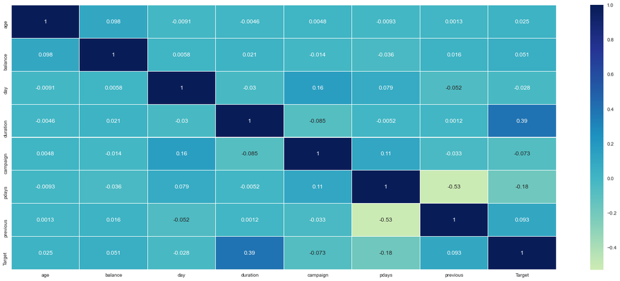

```python
# Getting Correlation
plt.figure(figsize=(25,10))
sns.heatmap(td.corr(),annot=True,linewidths=.1,center=0,cmap="YlGnBu")
```

Observation:

```
Duration seems to be somewhat correlated with Target.

pdays and previous are also somewhat correlated.

day and campaign also have little correlation
```

#### name, meaning, range of values observed, central values (mean and median), standard deviation and quartiles, analysis of the body of distributions / tails, missing values, outliers

```python
int_cols={'age','balance','day','duration','campaign','pdays','previous','Target'}
for i in int_cols:
    print('Column >>',i)
    print('\tData Type >>', td[i].dtype)
    print('\tSkewness is >>', td[i].skew())
    print('\tMin is >>', td[i].min())
    print('\tMax is >>', td[i].max())
    print('\tMean is >>',td[i].mean())
    print('\tMedian is >>',td[i].median())
    print('\tStd Dev is >>',td[i].std())
    print('\tRange >>',td[i].max()-td[i].min())
    print('\t25% quartile is >>',td[i].quantile(q=.25))
    print('\t50% quartile is >>',td[i].quantile(q=.5))
    print('\t75% quartile is >>',td[i].quantile(q=.75))
    print('\tIQR is >>',td[i].quantile(q=.75)-td[i].quantile(q=.25))
```

```
Column >> duration
	Data Type >> int64
	Skewness is >> 3.144318099423456
	Min is >> 0
	Max is >> 4918
	Mean is >> 258.1630797814691
	Median is >> 180.0
	Std Dev is >> 257.52781226517095
	Range >> 4918
	25% quartile is >> 103.0
	50% quartile is >> 180.0
	75% quartile is >> 319.0
	IQR is >> 216.0
Column >> campaign
	Data Type >> int64
	Skewness is >> 4.898650166179674
	Min is >> 1
	Max is >> 63
	Mean is >> 2.763840658246887
	Median is >> 2.0
	Std Dev is >> 3.0980208832802205
	Range >> 62
	25% quartile is >> 1.0
	50% quartile is >> 2.0
	75% quartile is >> 3.0
	IQR is >> 2.0
Column >> pdays
	Data Type >> int64
	Skewness is >> -1.7486166306290034
	Min is >> 1
	Max is >> 950
	Mean is >> 817.5142774988387
	Median is >> 950.0
	Std Dev is >> 284.5820046969831
	Range >> 949
	25% quartile is >> 950.0
	50% quartile is >> 950.0
	75% quartile is >> 950.0
	IQR is >> 0.0
Column >> Target
```

[output cut: 49 more lines]

```
	75% quartile is >> 21.0
	IQR is >> 13.0
Column >> balance
	Data Type >> int64
	Skewness is >> 8.470445228391881
	Min is >> 0
	Max is >> 102127
	Mean is >> 1388.7340691424654
	Median is >> 448.0
	Std Dev is >> 3029.530442327641
	Range >> 102127
	25% quartile is >> 72.0
	50% quartile is >> 448.0
	75% quartile is >> 1428.0
	IQR is >> 1356.0
```

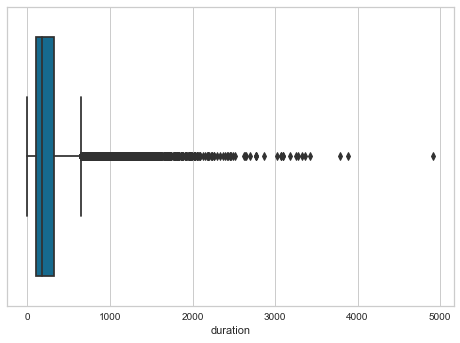

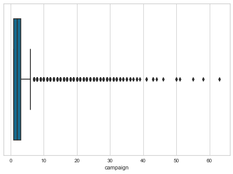

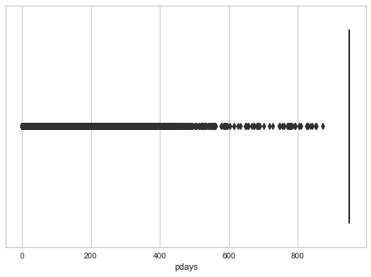

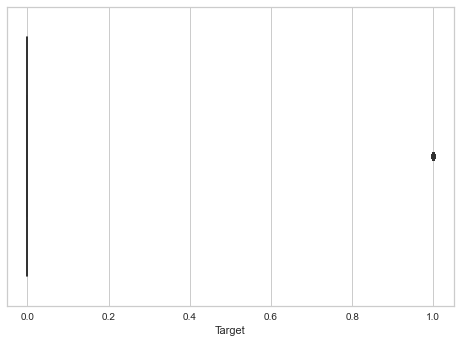

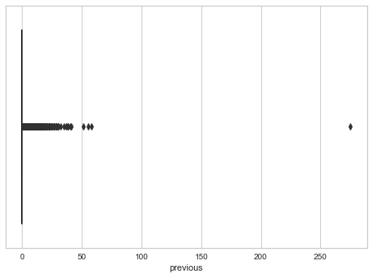

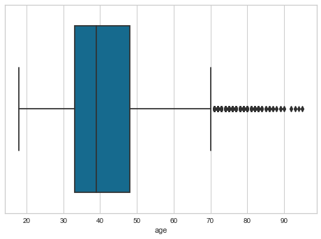

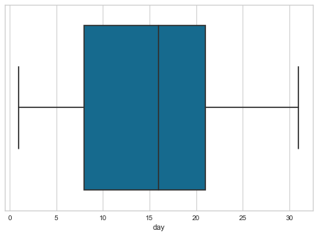

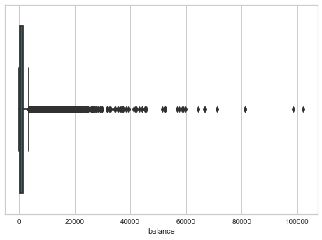

```python
## Box Plots for 'age','balance','day','duration','campaign','pdays','previous','Target'
for i in int_cols:
    sns.boxplot(x=td[i])
    plt.show()
```

Observation:

[output not shown]

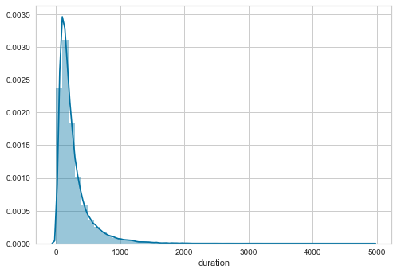

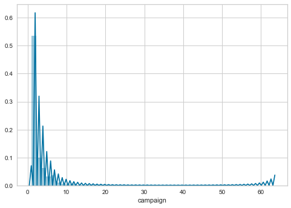

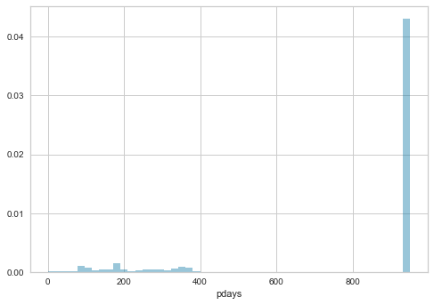

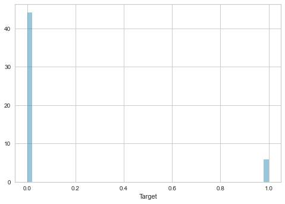

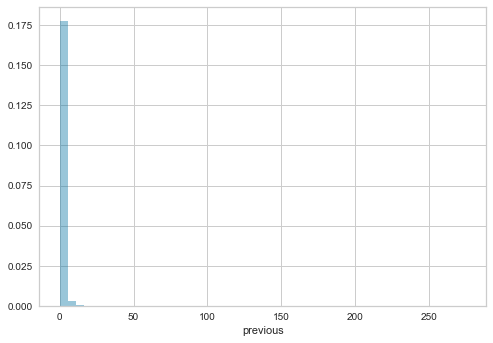

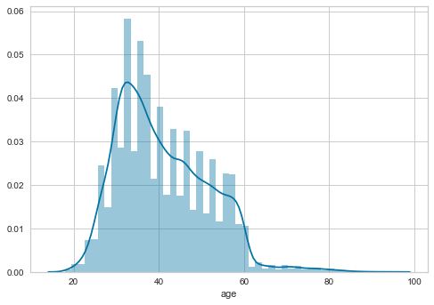

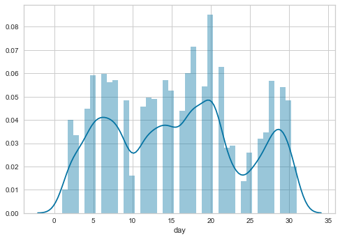

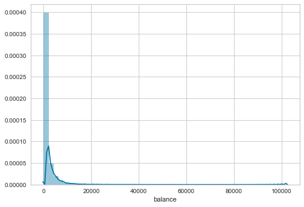

```python
### distplot for continous columns 'age','balance','day','duration','campaign','pdays','previous','Target'
for i in int_cols:
    sns.distplot(td[i])
    plt.show()
```

Observation:

[output not shown]

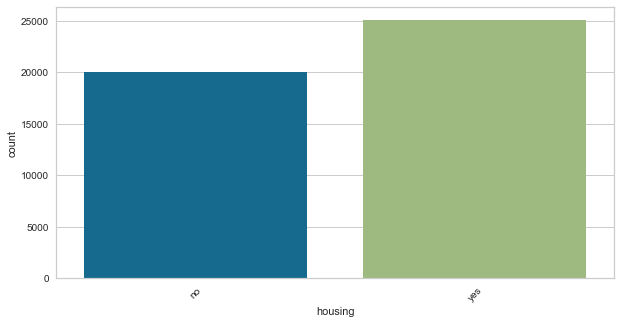

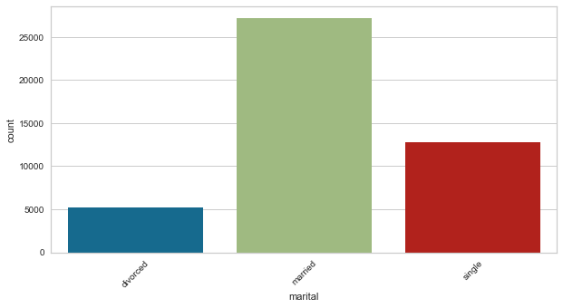

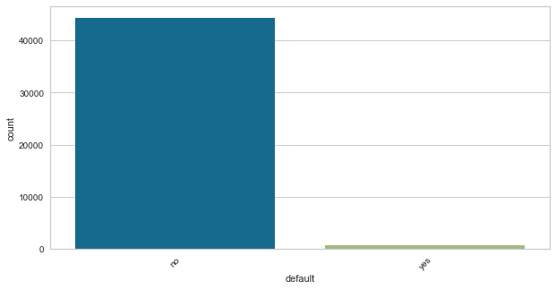

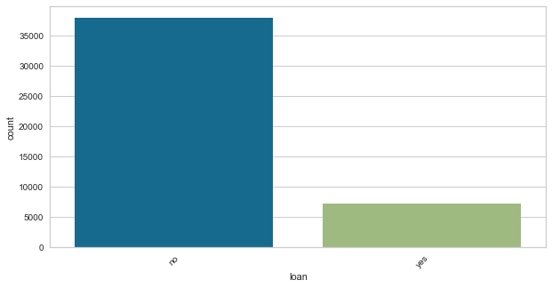

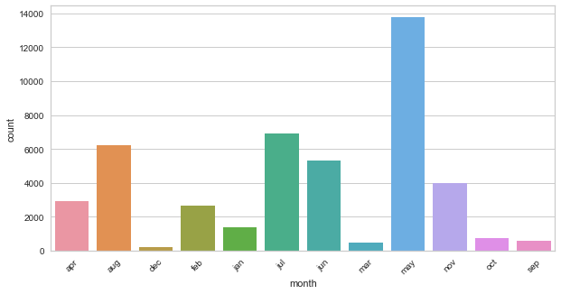

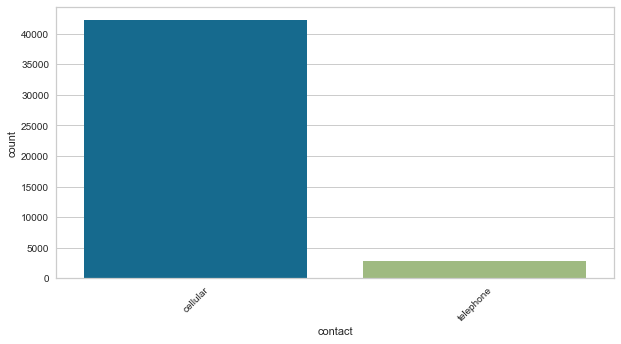

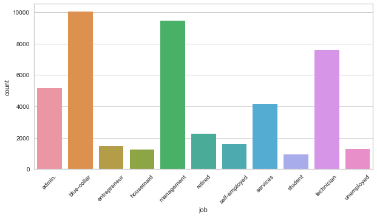

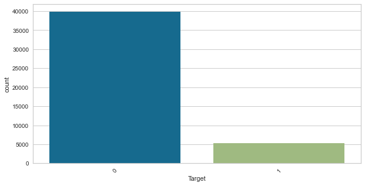

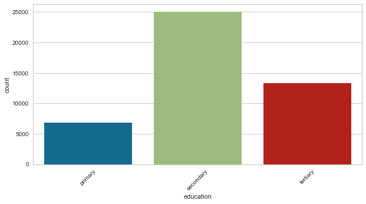

```python
# Plots for Categorical columns
cat_cols={'job','marital','education','default','housing','loan','contact','Target','month'}
for i in cat_cols:
    plt.figure(figsize=(10,5))
    plt.xticks(rotation=45)
    sns.countplot(td[i])
    plt.show()
```

Observation:

```
1. The dataset contains more people with housing loan and secondary education
2. The dataset contains more people with no credit defaults and no personal loan and not subscribed to Term Deposit
3. Clients were mostly contacted in May
4. Most bank clients are blue-collar, management and technicians and larger chunck is married
5. Most used communication medium was cell-phone
```